# CS422 Section 01

Kaiyue Ma

# 2.1

```r
library(rpart)
library(caret)
```

```r
library(rpart.plot)
library(ROCR)
library(lattice)
library(ggplot2)
set.seed(1122)

setwd("/Users/michael/Codes/R/2")
train <- read.csv("adult-train.csv", header=T, sep=",")
test <- read.csv("adult-test.csv", header=T, sep=",")
```

### (a)

```r
#bulid the pure set
train[train=="?"]<-NA
pure_train <- na.omit(train)

test[test=="?"]<-NA
pure_test <- na.omit(test)
```

### (b)

```r
#bulid the tree
model_income <- rpart(pure_train$income ~., method="class", data = pure_train)
print(model_income)
```

```
## n= 30161
##
## node), split, n, loss, yval, (yprob)
##       * denotes terminal node
##
##  1) root 30161 7508 <=50K (0.75106926 0.24893074)
##    2) relationship=Not-in-family,Other-relative,Own-child,Unmarried 16292 1135 <=50K (0.93033391 0.06966609)
##      4) capital_gain< 7073.5 15992  845 <=50K (0.94716108 0.05283892) *
##      5) capital_gain>=7073.5 300   10 >50K (0.03333333 0.96666667) *
##    3) relationship=Husband,Wife 13869 6373 <=50K (0.54048598 0.45951402)
##      6) education=10th,11th,12th,1st-4th,5th-6th,7th-8th,9th,Assoc-acdm,Assoc-voc,HS-grad,Preschool,Some-college 9719 3322 <=50K (0.65819529 0.34180471)
##       12) capital_gain< 5095.5 9219 2831 <=50K (0.69291680 0.30708320) *
##       13) capital_gain>=5095.5 500    9 >50K (0.01800000 0.98200000) *
##      7) education=Bachelors,Doctorate,Masters,Prof-school 4150 1099 >50K (0.26481928 0.73518072) *
```

```r
summary(model_income)
```

```
## Call:
## rpart(formula = pure_train$income ~ ., data = pure_train, method = "class")
##   n= 30161
##
##           CP nsplit rel error    xerror        xstd
## 1 0.12999467      0 1.0000000 1.0000000 0.010001793
## 2 0.06419819      2 0.7400107 0.7400107 0.008966969
## 3 0.03729355      3 0.6758125 0.6758125 0.008652716
## 4 0.01000000      4 0.6385189 0.6385189 0.008457392
##
## Variable importance
##   relationship marital_status   capital_gain      education  education_num
##             24             23             10              9              9
##            sex     occupation            age hours_per_week
##              8              7              5              3
##
## Node number 1: 30161 observations,    complexity param=0.1299947
##   predicted class=<=50K  expected loss=0.2489307  P(node) =1
##     class counts: 22653  7508
##    probabilities: 0.751 0.249
##   left son=2 (16292 obs) right son=3 (13869 obs)
##   Primary splits:
##       relationship   splits as  RLLLLR, improve=2277.164, (0 missing)
##       marital_status splits as  LRRLLLL, improve=2244.398, (0 missing)
##       capital_gain   < 5119   to the left,  improve=1540.825, (0 missing)
##       education      splits as  LLLLLLLLLRRLRLRL, improve=1193.769, (0 missing)
##       education_num  < 12.5   to the left,  improve=1193.769, (0 missing)
##   Surrogate splits:
##       marital_status splits as  LRRLLLL, agree=0.993, adj=0.984, (0 split)
##       sex            splits as  LR, agree=0.691, adj=0.328, (0 split)
##       age            < 33.5   to the left,  agree=0.645, adj=0.229, (0 split)
##       occupation     splits as  -LLRRRLLLLRRLLR, agree=0.620, adj=0.175, (0 split)
##       hours_per_week < 43.5   to the left,  agree=0.604, adj=0.138, (0 split)
##
## Node number 2: 16292 observations,    complexity param=0.03729355
##   predicted class=<=50K  expected loss=0.06966609  P(node) =0.5401678
##     class counts: 15157  1135
##    probabilities: 0.930 0.070
##   left son=4 (15992 obs) right son=5 (300 obs)
##   Primary splits:
```

[output cut: 45 more lines]

```
##
## Node number 7: 4150 observations
##   predicted class=>50K   expected loss=0.2648193  P(node) =0.1375949
##     class counts:  1099  3051
##    probabilities: 0.265 0.735
##
## Node number 12: 9219 observations
##   predicted class=<=50K  expected loss=0.3070832  P(node) =0.3056596
##     class counts:  6388  2831
##    probabilities: 0.693 0.307
##
## Node number 13: 500 observations
##   predicted class=>50K   expected loss=0.018  P(node) =0.0165777
##     class counts:     9   491
##    probabilities: 0.018 0.982
```

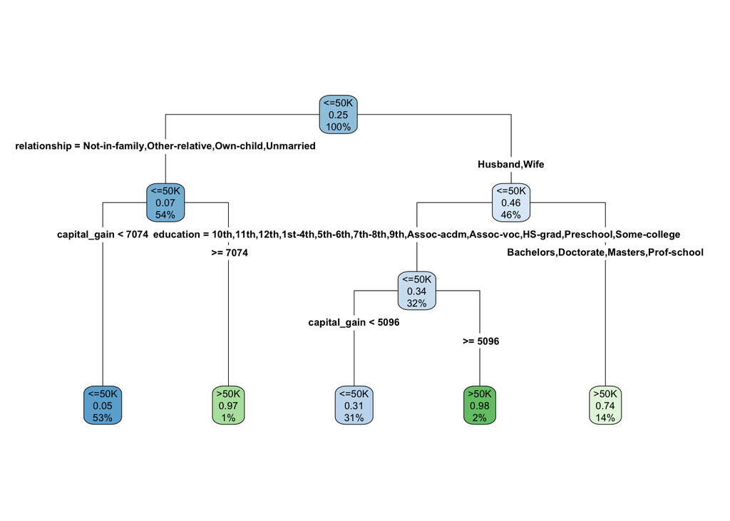

```r
rpart.plot(model_income, fallen.leaves = T, type = 4)
```

#### (i) The top three important predictors in the model are : relationship, marital_status and capital_gain.

#### (ii) The first split is done on predictor Relationship.

#### The predicted class of the first node is ‘<=50K’.

#### Distribution of observations between the “<=50K” and “>50K” classes at this node is 0.75106926 and 0.24893074.

### (c)

```r
#predict
pred <- predict(model_income, pure_test, type="class")
```

```r
test_num_pos <- sum(pure_test$income == ">50K")
test_num_neg <- sum(pure_test$income == "<=50K")

tp <- sum(pure_test$income == ">50K" & pred == ">50K")
tn <- sum(pure_test$income == "<=50K" & pred == "<=50K")
table(pred, pure_test$income)
```

```
##
## pred    <=50K  >50K
##   <=50K 10772  1837
##   >50K    588  1863
```

```r
confusionMatrix(pred, pure_test$income)
```

```
## Confusion Matrix and Statistics
##
##           Reference
## Prediction <=50K  >50K
##      <=50K 10772  1837
##      >50K    588  1863
##
##                Accuracy : 0.839
##                  95% CI : (0.833, 0.8448)
##     No Information Rate : 0.7543
##     P-Value [Acc > NIR] : < 2.2e-16
##
##                   Kappa : 0.5098
##  Mcnemar's Test P-Value : < 2.2e-16
##
##             Sensitivity : 0.9482
##             Specificity : 0.5035
##          Pos Pred Value : 0.8543
##          Neg Pred Value : 0.7601
##              Prevalence : 0.7543
##          Detection Rate : 0.7153
##    Detection Prevalence : 0.8373
##       Balanced Accuracy : 0.7259
##
##        'Positive' Class : <=50K
##
```

#### (i) The balanced accuracy of the model is 0.726.

#### (ii) The balanced error rate of the model is 0.274.

#### (iii) Sensitivity : 0.948 Specificity : 0.504

#### (iv)

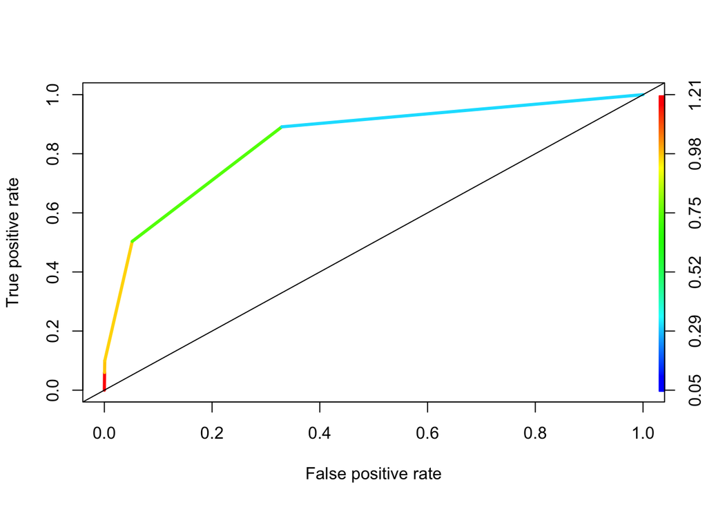

```r
# ROC curve

pred.rocr <- predict(model_income, newdata=pure_test, type="prob")[,2]
f.pred <- prediction(pred.rocr, pure_test$income)
f.perf <- performance(f.pred, "tpr", "fpr")
plot(f.perf, colorize=T, lwd=3)
abline(0,1)
```

```r
auc <- performance(f.pred, measure = "auc")
cat(paste("The area under curve (AUC) for this model is ", round(auc@y.values[[1]], 3)))
```

```
## The area under curve (AUC) for this model is  0.843
```

#### The area under curve (AUC) for this model is 0.843

### (d)

```r
options("digits"=5)
printcp(model_income)
```

```
##
## Classification tree:
## rpart(formula = pure_train$income ~ ., data = pure_train, method = "class")
##
## Variables actually used in tree construction:
## [1] capital_gain education    relationship
##
## Root node error: 7508/30161 = 0.249
##
## n= 30161
##
##       CP nsplit rel error xerror    xstd
## 1 0.1300      0     1.000  1.000 0.01000
## 2 0.0642      2     0.740  0.740 0.00897
## 3 0.0373      3     0.676  0.676 0.00865
## 4 0.0100      4     0.639  0.639 0.00846
```

#### The tree won’t benefit from a pruning, it will not significant benefit the tree. Because the 4th line’s xerror rate is the smallest in the CP table. Look down from the first line the xerror rate it didn’t increase.

### (e)

```r
#number
train_num_pos <- sum(pure_train$income == ">50K")
train_num_neg <- sum(pure_train$income == "<=50K")
```

#### (i) The numver of observations are in the class “<=50K” is : 22653

#### The numver of observations are in the class “>50K” is : 7508

#### (ii)

```r
#sample
temp_neg <- pure_train[pure_train$income == "<=50K",]
sample_pos <- temp_neg[sample(nrow(temp_neg), train_num_pos, replace = F), ]

#merge
train_pos <- pure_train[which(pure_train$income == ">50K"),]
new_train <- rbind(train_pos, sample_pos)

#random
new_train <- new_train[sample(nrow(new_train), nrow(new_train), replace = F),]
```

#### (iii)

```r
new_model_income <- rpart(new_train$income ~., method="class", data = new_train)
```

```r
new_pred <- predict(new_model_income, pure_test, type="class")
confusionMatrix(new_pred, pure_test$income)
```

```
## Confusion Matrix and Statistics
##
##           Reference
## Prediction <=50K >50K
##      <=50K  8879  609
##      >50K   2481 3091
##
##                Accuracy : 0.795
##                  95% CI : (0.788, 0.801)
##     No Information Rate : 0.754
##     P-Value [Acc > NIR] : <2e-16
##
##                   Kappa : 0.527
##  Mcnemar's Test P-Value : <2e-16
##
##             Sensitivity : 0.782
##             Specificity : 0.835
##          Pos Pred Value : 0.936
##          Neg Pred Value : 0.555
##              Prevalence : 0.754
##          Detection Rate : 0.590
##    Detection Prevalence : 0.630
##       Balanced Accuracy : 0.809
##
##        'Positive' Class : <=50K
##
```

###### (i) The balanced accuracy of the model is 0.809.

###### (ii) The balanced error rate of the model is 0.191.

###### (iii) Sensitivity : 0.782 Specificity : 0.835

###### (iv)

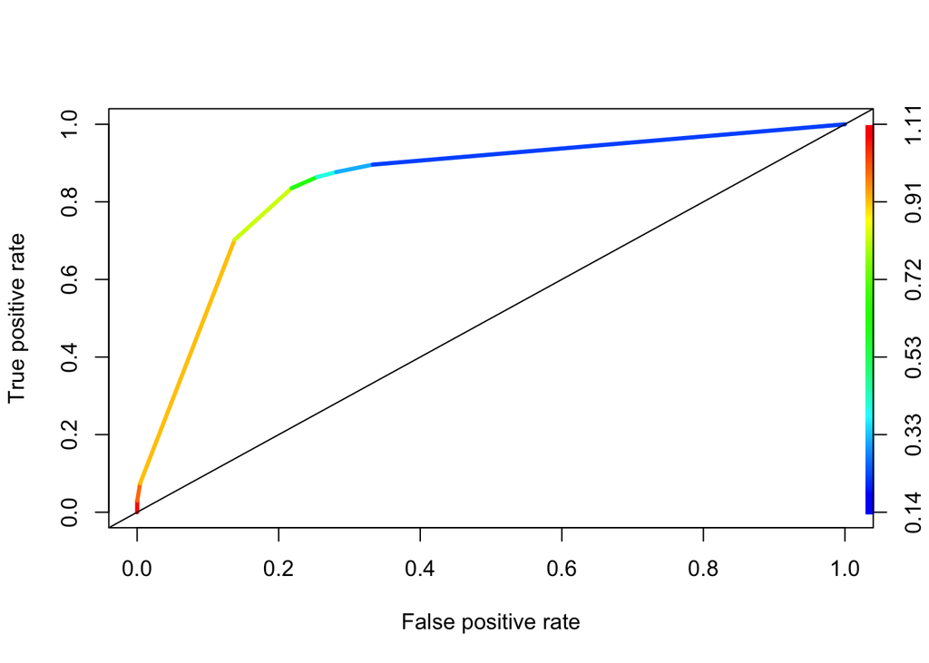

```r
# ROC curve

pred.rocr <- predict(new_model_income, newdata=pure_test, type="prob")[,2]
f.pred <- prediction(pred.rocr, pure_test$income)
f.perf <- performance(f.pred, "tpr", "fpr")
plot(f.perf, colorize=T, lwd=3)
abline(0,1)
```

```r
auc <- performance(f.pred, measure = "auc")
cat(paste("The area under curve (AUC) for this model is ", round(auc@y.values[[1]], 3)))
```

```
## The area under curve (AUC) for this model is  0.846
```

##### The area under curve (AUC) for this model is 0.846

### (f)

#### In(C): The Balanced accuracy of the model is 0.726, the Sensitivity is 0.948 and the Specificity is 0.504 and the area under curve (AUC) for this model is 0.843.

#### In(e): The balanced accuracy of the model is 0.809, the Sensitivity is 0.782 and the Specificity is 0.835 and the area under curve (AUC) for this model is 0.846.

#### It shows that the Balanced accuracy and Specificity are increasing but the Sensitivity is decreasing. The area under curve(AUC) has little change.

# 2.2

```r
library(randomForest)
```

### (a)

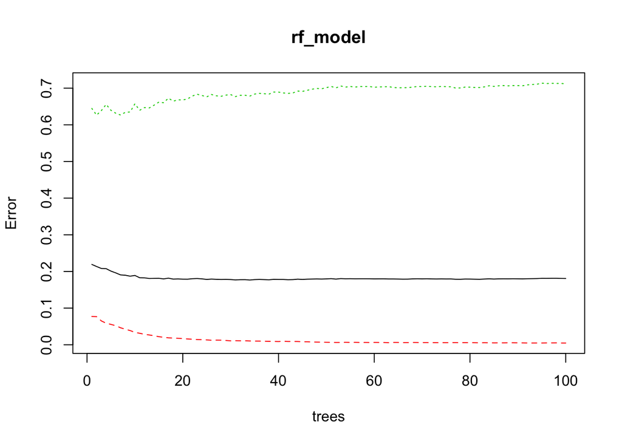

```r
rf_model <- randomForest(income ~ ., data=pure_train, ntree = 100, importance = T)

plot(rf_model)
```

```r
rf_pred <- predict(rf_model, pure_test, type="class")
confusionMatrix(rf_pred, as.factor(pure_test$income))
```

```
## Confusion Matrix and Statistics
##
##           Reference
## Prediction <=50K  >50K
##      <=50K 11324  2690
##      >50K     36  1010
##
##                Accuracy : 0.819
##                  95% CI : (0.813, 0.825)
##     No Information Rate : 0.754
##     P-Value [Acc > NIR] : <2e-16
##
##                   Kappa : 0.356
##  Mcnemar's Test P-Value : <2e-16
##
##             Sensitivity : 0.997
##             Specificity : 0.273
##          Pos Pred Value : 0.808
##          Neg Pred Value : 0.966
##              Prevalence : 0.754
##          Detection Rate : 0.752
##    Detection Prevalence : 0.931
##       Balanced Accuracy : 0.635
##
##        'Positive' Class : <=50K
##
```

#### (iv) The numver of observations are in the class “<=50K” is : 22653

#### The numver of observations are in the class “>50K” is : 7508

#### (v) Yes, because there are more data in “<=50k” in train set, thus the sensitivity will be higher compare to the specificity.

#### For MeanDecreaseAccuracy, capital_gain is the most important variable and native_country is the least importatn variable.

#### For MeanDecreaseGini, capital_gain is the most important variable and race is the least importatn variable.

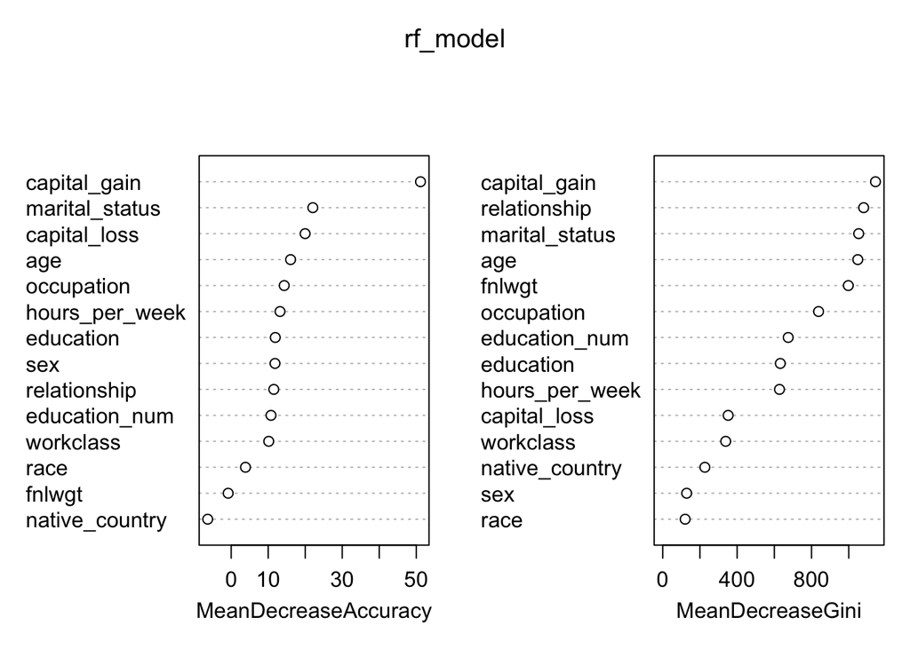

```r
varImpPlot(rf_model)
```

#### (vii) The number of variables tried at each split is 3.

```r
print(rf_model)
```

```
##
## Call:
##  randomForest(formula = income ~ ., data = pure_train, ntree = 100,      importance = T)
##                Type of random forest: classification
##                      Number of trees: 100
## No. of variables tried at each split: 3
##
##         OOB estimate of  error rate: 18.08%
## Confusion matrix:
##       <=50K >50K class.error
## <=50K 22545  108   0.0047676
## >50K   5346 2162   0.7120405
```

### (b)

```
## mtry = 3  OOB error = 18.19%
## Searching left ...
## mtry = 2     OOB error = 18.1%
## 0.0049225 0.01
## Searching right ...
## mtry = 4     OOB error = 18.19%
## -0.00018232 0.01
```

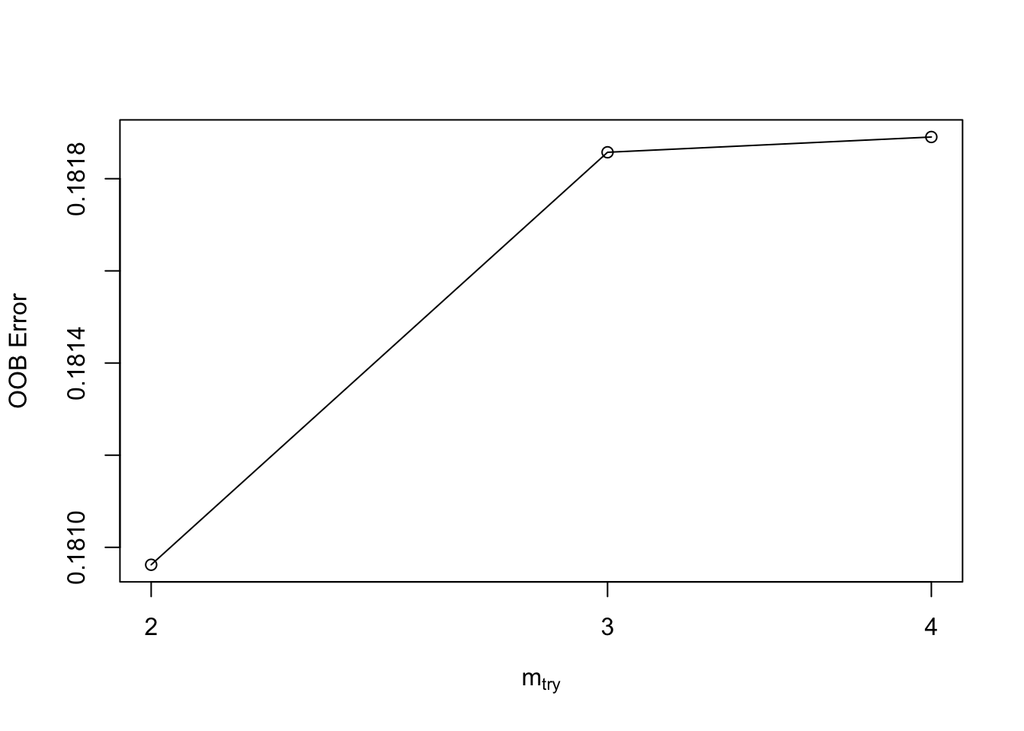

```r
mtry <- tuneRF(pure_train[,-15], pure_train$income, ntreeTry=500, stepFactor=1.5,improve=0.01, trace=TRUE, plot=TRUE)
```

#### (i) The default value of mtry given the number of predictors in the model is 3. #### (ii) The optimal value of mtry suggested by the method is 2. #### (iii)

```r
new_rf_model <- randomForest(income ~ ., data=pure_train, importance = T, mtry = 2)
new_rf_pred <- predict(new_rf_model, pure_test, type="class")
confusionMatrix(new_rf_pred, as.factor(pure_test$income))
```

```
## Confusion Matrix and Statistics
##
##           Reference
## Prediction <=50K  >50K
##      <=50K 11319  2615
##      >50K     41  1085
##
##                Accuracy : 0.824
##                  95% CI : (0.817, 0.83)
##     No Information Rate : 0.754
##     P-Value [Acc > NIR] : <2e-16
##
##                   Kappa : 0.378
##  Mcnemar's Test P-Value : <2e-16
##
##             Sensitivity : 0.996
##             Specificity : 0.293
##          Pos Pred Value : 0.812
##          Neg Pred Value : 0.964
##              Prevalence : 0.754
##          Detection Rate : 0.752
##    Detection Prevalence : 0.925
##       Balanced Accuracy : 0.645
##
##        'Positive' Class : <=50K
##
```

###### (1) The balanced accuracy of the model is ~0.645.

###### (2) The accuracy of the model is ~0.824.

###### (3) Sensitivity : ~0.996 Specificity : ~0.293

###### (5)

###### For MeanDecreaseAccuracy, capital_gain is the most important variable and native_country is the least importatn variable.

###### For MeanDecreaseGini, capital_gain is the most important variable and race is the least importatn variable.

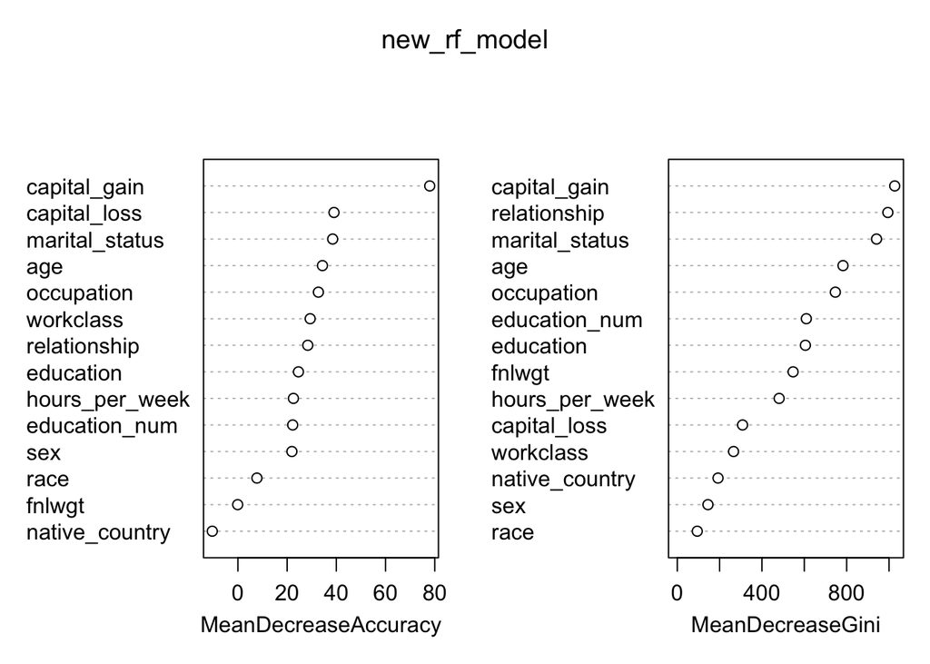

```r
varImpPlot(new_rf_model)
```

```r
bal_rf_model <- randomForest(income ~ ., data=new_train, importance = T)
bal_rf_pred <- predict(bal_rf_model, pure_test, type="class")
confusionMatrix(bal_rf_pred, as.factor(pure_test$income))
```

```
## Confusion Matrix and Statistics
##
##           Reference
## Prediction <=50K  >50K
##      <=50K 11144  2316
##      >50K    216  1384
##
##                Accuracy : 0.832
##                  95% CI : (0.826, 0.838)
##     No Information Rate : 0.754
##     P-Value [Acc > NIR] : <2e-16
##
##                   Kappa : 0.439
##  Mcnemar's Test P-Value : <2e-16
##
##             Sensitivity : 0.981
##             Specificity : 0.374
##          Pos Pred Value : 0.828
##          Neg Pred Value : 0.865
##              Prevalence : 0.754
##          Detection Rate : 0.740
##    Detection Prevalence : 0.894
##       Balanced Accuracy : 0.678
##
##        'Positive' Class : <=50K
##
```

# 2.3

```r
library(arules)
```

```r
library(arulesViz)
library(viridisLite)

groceries <- read.transactions("groceries.csv", sep = ",")
```

### (i)

```r
rules <- apriori(groceries)
```

```
## Apriori
##
## Parameter specification:
##  confidence minval smax arem  aval originalSupport maxtime support minlen
##         0.8    0.1    1 none FALSE            TRUE       5     0.1      1
##  maxlen target   ext
##      10  rules FALSE
##
## Algorithmic control:
##  filter tree heap memopt load sort verbose
##     0.1 TRUE TRUE  FALSE TRUE    2    TRUE
##
## Absolute minimum support count: 983
##
## set item appearances ...[0 item(s)] done [0.00s].
## set transactions ...[169 item(s), 9835 transaction(s)] done [0.00s].
## sorting and recoding items ... [8 item(s)] done [0.00s].
## creating transaction tree ... done [0.00s].
## checking subsets of size 1 2 done [0.00s].
## writing ... [0 rule(s)] done [0.00s].
## creating S4 object  ... done [0.00s].
```

#### 0 rules I get at this support value.

### (ii)

```r
rules_1 <- apriori(groceries, parameter = list(support=0.001))
```

```
## Apriori
##
## Parameter specification:
##  confidence minval smax arem  aval originalSupport maxtime support minlen
##         0.8    0.1    1 none FALSE            TRUE       5   0.001      1
##  maxlen target   ext
##      10  rules FALSE
##
## Algorithmic control:
##  filter tree heap memopt load sort verbose
##     0.1 TRUE TRUE  FALSE TRUE    2    TRUE
##
## Absolute minimum support count: 9
##
## set item appearances ...[0 item(s)] done [0.00s].
## set transactions ...[169 item(s), 9835 transaction(s)] done [0.00s].
## sorting and recoding items ... [157 item(s)] done [0.00s].
## creating transaction tree ... done [0.00s].
## checking subsets of size 1 2 3 4 5 6 done [0.01s].
## writing ... [410 rule(s)] done [0.00s].
## creating S4 object  ... done [0.00s].
```

#### Support value is 0.001 when get at least 400 rules.

### (iii)

```r
summary(groceries)
```

```
## transactions as itemMatrix in sparse format with
##  9835 rows (elements/itemsets/transactions) and
##  169 columns (items) and a density of 0.026091
##
## most frequent items:
##       whole milk other vegetables       rolls/buns             soda
##             2513             1903             1809             1715
##           yogurt          (Other)
##             1372            34055
##
## element (itemset/transaction) length distribution:
## sizes
##    1    2    3    4    5    6    7    8    9   10   11   12   13   14   15
## 2159 1643 1299 1005  855  645  545  438  350  246  182  117   78   77   55
##   16   17   18   19   20   21   22   23   24   26   27   28   29   32
##   46   29   14   14    9   11    4    6    1    1    1    1    3    1
##
##    Min. 1st Qu.  Median    Mean 3rd Qu.    Max.
##    1.00    2.00    3.00    4.41    6.00   32.00
##
## includes extended item information - examples:
##             labels
## 1 abrasive cleaner
## 2 artif. sweetener
## 3   baby cosmetics
```

```r
sort(itemFrequency(groceries),decreasing = T)
```

```
##                whole milk          other vegetables
##                0.25551601                0.19349263
##                rolls/buns                      soda
##                0.18393493                0.17437722
##                    yogurt             bottled water
##                0.13950178                0.11052364
##           root vegetables            tropical fruit
##                0.10899847                0.10493137
##             shopping bags                   sausage
##                0.09852567                0.09395018
##                    pastry              citrus fruit
##                0.08896797                0.08276563
##              bottled beer                newspapers
##                0.08052872                0.07981698
##               canned beer                 pip fruit
##                0.07768175                0.07564820
##     fruit/vegetable juice        whipped/sour cream
##                0.07229283                0.07168277
##               brown bread             domestic eggs
##                0.06487036                0.06344687
##               frankfurter                 margarine
##                0.05897306                0.05856634
##                    coffee                      pork
##                0.05805796                0.05765125
##                    butter                      curd
##                0.05541434                0.05327911
##                      beef                   napkins
##                0.05246568                0.05236401
##                 chocolate         frozen vegetables
##                0.04961871                0.04809354
##                   chicken               white bread
##                0.04290798                0.04209456
##              cream cheese                   waffles
##                0.03965430                0.03843416
##               salty snack  long life bakery product
##                0.03782410                0.03741739
##                   dessert                     sugar
##                0.03711235                0.03385867
##                  UHT-milk                   berries
##                0.03345196                0.03324860
```

[output cut: 115 more lines]

```
##                0.00122013                0.00111845
##           rubbing alcohol                   liqueur
##                0.00101678                0.00091510
##           make up remover            salad dressing
##                0.00081342                0.00081342
##                    whisky            toilet cleaner
##                0.00081342                0.00071174
##            baby cosmetics            frozen chicken
##                0.00061007                0.00061007
##                      bags           kitchen utensil
##                0.00040671                0.00040671
##     preservation products                 baby food
##                0.00020336                0.00010168
##      sound storage medium
##                0.00010168
```

#### The most frequently bought item is whole milk. Whole milk’s frequency is 0.2555160142.

### (iv)

#### The least frequently bought item is sound storage medium. And its frequency is 0.0001016777.

### (v)

```r
inspect(head(rules_1, by = "support",5))
```

```
##     lhs                   rhs                  support confidence   lift count
## [1] {citrus fruit,
##      root vegetables,
##      tropical fruit,
##      whole milk}       => {other vegetables} 0.0031520    0.88571 4.5775    31
## [2] {curd,
##      domestic eggs,
##      other vegetables} => {whole milk}       0.0028470    0.82353 3.2230    28
## [3] {curd,
##      hamburger meat}   => {whole milk}       0.0025419    0.80645 3.1562    25
## [4] {herbs,
##      rolls/buns}       => {whole milk}       0.0024403    0.80000 3.1309    24
## [5] {herbs,
##      tropical fruit}   => {whole milk}       0.0023386    0.82143 3.2148    23
```

### (vi)

```r
inspect(head(rules_1, by = "confidence",5))
```

```
##     lhs                     rhs            support confidence   lift count
## [1] {rice,
##      sugar}              => {whole milk} 0.0012201          1 3.9136    12
## [2] {canned fish,
##      hygiene articles}   => {whole milk} 0.0011185          1 3.9136    11
## [3] {butter,
##      rice,
##      root vegetables}    => {whole milk} 0.0010168          1 3.9136    10
## [4] {flour,
##      root vegetables,
##      whipped/sour cream} => {whole milk} 0.0017285          1 3.9136    17
## [5] {butter,
##      domestic eggs,
##      soft cheese}        => {whole milk} 0.0010168          1 3.9136    10
```

### (vii)

```r
inspect(tail(rules_1, by = "support",5))
```

```
##     lhs                     rhs                  support confidence   lift count
## [1] {oil,
##      other vegetables,
##      tropical fruit,
##      whole milk,
##      yogurt}             => {root vegetables}  0.0010168    0.90909 8.3404    10
## [2] {butter,
##      domestic eggs,
##      other vegetables,
##      tropical fruit,
##      yogurt}             => {whole milk}       0.0010168    0.90909 3.5579    10
## [3] {butter,
##      domestic eggs,
##      tropical fruit,
##      whole milk,
##      yogurt}             => {other vegetables} 0.0010168    0.83333 4.3068    10
## [4] {citrus fruit,
##      other vegetables,
##      root vegetables,
##      whipped/sour cream,
##      yogurt}             => {whole milk}       0.0010168    0.83333 3.2614    10
## [5] {citrus fruit,
##      root vegetables,
##      whipped/sour cream,
##      whole milk,
##      yogurt}             => {other vegetables} 0.0010168    0.90909 4.6983    10
```

### (viii)

```r
inspect(tail(rules_1, by = "confidence",5))
```

```
##     lhs                     rhs                  support confidence   lift count
## [1] {pip fruit,
##      tropical fruit,
##      whipped/sour cream,
##      whole milk}         => {other vegetables} 0.0016268        0.8 4.1345    16
## [2] {citrus fruit,
##      other vegetables,
##      sausage,
##      whipped/sour cream} => {whole milk}       0.0012201        0.8 3.1309    12
## [3] {citrus fruit,
##      sausage,
##      whipped/sour cream,
##      whole milk}         => {other vegetables} 0.0012201        0.8 4.1345    12
## [4] {citrus fruit,
##      tropical fruit,
##      whipped/sour cream,
##      yogurt}             => {whole milk}       0.0012201        0.8 3.1309    12
## [5] {rolls/buns,
##      root vegetables,
##      tropical fruit,
##      whipped/sour cream} => {other vegetables} 0.0012201        0.8 4.1345    12
```